# EDA of Titanic Data

David West

8/13/2020

# 1 Intro

This is an EDA of the [Titanic data set](https://www.kaggle.com/c/titanic/) on Kaggle. The objective is to understand the data set and eventually create a predictive model for survival rate.

## 1.1 Data Dictionary

The following descriptions were provided on Kaggle.

```r
dictionary
```

```
## # A tibble: 10 x 3
##    Variable Definition                        Key
##    <chr>    <chr>                             <chr>
##  1 survival Survival                          "0 = No, 1 = Yes"
##  2 pclass   Ticket class                      "1 = 1st, 2 = 2nd, 3 = 3rd"
##  3 sex      Sex                               ""
##  4 Age      Age in years                      ""
##  5 sibsp    # of siblings / spouses aboard t~ ""
##  6 parch    # of parents / children aboard t~ ""
##  7 ticket   Ticket number                     ""
##  8 fare     Passenger fare                    ""
##  9 cabin    Cabin number                      ""
## 10 embarked Port of Embarkation               "C = Cherbourg, Q = Queenstown, S~
```

The following notes were provided about the variables:  
pclass: A proxy for socio-economic status (SES)  
1st = Upper  
2nd = Middle  
3rd = Lower

age: Age is fractional if less than 1. If the age is estimated, is it in the form of xx.5

sibsp: The dataset defines family relations in this way…  
Sibling = brother, sister, stepbrother, stepsister  
Spouse = husband, wife (mistresses and fiancés were ignored)

parch: The dataset defines family relations in this way…  
Parent = mother, father  
Child = daughter, son, stepdaughter, stepson  
Some children travelled only with a nanny, therefore parch=0 for them.

# 2 Importing the Data

The script below imports the data into R.

```r
train <- read_csv(here::here("data","raw","train.csv"))
test <- read_csv(here::here("data","raw","test.csv"))
submission_example <- read_csv(here::here("data","raw","gender_submission.csv"))
```

# 3 First Look

Let’s look at the training data.

```r
head(train)
```

```
## # A tibble: 6 x 12
##   PassengerId Survived Pclass Name  Sex     Age SibSp Parch Ticket  Fare Cabin
##         <dbl>    <dbl>  <dbl> <chr> <chr> <dbl> <dbl> <dbl> <chr>  <dbl> <chr>
## 1           1        0      3 Brau~ male     22     1     0 A/5 2~  7.25 <NA>
## 2           2        1      1 Cumi~ fema~    38     1     0 PC 17~ 71.3  C85
## 3           3        1      3 Heik~ fema~    26     0     0 STON/~  7.92 <NA>
## 4           4        1      1 Futr~ fema~    35     1     0 113803 53.1  C123
## 5           5        0      3 Alle~ male     35     0     0 373450  8.05 <NA>
## 6           6        0      3 Mora~ male     NA     0     0 330877  8.46 <NA>
## # ... with 1 more variable: Embarked <chr>
```

```r
glimpse(train)
```

```
## Rows: 891
## Columns: 12
## $ PassengerId <dbl> 1, 2, 3, 4, 5, 6, 7, 8, 9, 10, 11, 12, 13, 14, 15, 16, ...
## $ Survived    <dbl> 0, 1, 1, 1, 0, 0, 0, 0, 1, 1, 1, 1, 0, 0, 0, 1, 0, 1, 0...
## $ Pclass      <dbl> 3, 1, 3, 1, 3, 3, 1, 3, 3, 2, 3, 1, 3, 3, 3, 2, 3, 2, 3...
## $ Name        <chr> "Braund, Mr. Owen Harris", "Cumings, Mrs. John Bradley ...
## $ Sex         <chr> "male", "female", "female", "female", "male", "male", "...
## $ Age         <dbl> 22, 38, 26, 35, 35, NA, 54, 2, 27, 14, 4, 58, 20, 39, 1...
## $ SibSp       <dbl> 1, 1, 0, 1, 0, 0, 0, 3, 0, 1, 1, 0, 0, 1, 0, 0, 4, 0, 1...
## $ Parch       <dbl> 0, 0, 0, 0, 0, 0, 0, 1, 2, 0, 1, 0, 0, 5, 0, 0, 1, 0, 0...
## $ Ticket      <chr> "A/5 21171", "PC 17599", "STON/O2. 3101282", "113803", ...
## $ Fare        <dbl> 7.2500, 71.2833, 7.9250, 53.1000, 8.0500, 8.4583, 51.86...
## $ Cabin       <chr> NA, "C85", NA, "C123", NA, NA, "E46", NA, NA, NA, "G6",...
## $ Embarked    <chr> "S", "C", "S", "S", "S", "Q", "S", "S", "S", "C", "S", ...
```

```r
summary(train)
```

```
##   PassengerId       Survived          Pclass          Name
##  Min.   :  1.0   Min.   :0.0000   Min.   :1.000   Length:891
##  1st Qu.:223.5   1st Qu.:0.0000   1st Qu.:2.000   Class :character
##  Median :446.0   Median :0.0000   Median :3.000   Mode  :character
##  Mean   :446.0   Mean   :0.3838   Mean   :2.309
##  3rd Qu.:668.5   3rd Qu.:1.0000   3rd Qu.:3.000
##  Max.   :891.0   Max.   :1.0000   Max.   :3.000
##
##      Sex                 Age            SibSp           Parch
##  Length:891         Min.   : 0.42   Min.   :0.000   Min.   :0.0000
##  Class :character   1st Qu.:20.12   1st Qu.:0.000   1st Qu.:0.0000
##  Mode  :character   Median :28.00   Median :0.000   Median :0.0000
##                     Mean   :29.70   Mean   :0.523   Mean   :0.3816
##                     3rd Qu.:38.00   3rd Qu.:1.000   3rd Qu.:0.0000
##                     Max.   :80.00   Max.   :8.000   Max.   :6.0000
##                     NA's   :177
##     Ticket               Fare           Cabin             Embarked
##  Length:891         Min.   :  0.00   Length:891         Length:891
##  Class :character   1st Qu.:  7.91   Class :character   Class :character
##  Mode  :character   Median : 14.45   Mode  :character   Mode  :character
##                     Mean   : 32.20
##                     3rd Qu.: 31.00
##                     Max.   :512.33
##
```

Now, let’s look at each variable one at a time.

## 3.1 PassengerID

I’m guessing this a unique identifier for each passenger. Below is a quick summary:

```r
summary(train$PassengerId)
```

```
##    Min. 1st Qu.  Median    Mean 3rd Qu.    Max.
##     1.0   223.5   446.0   446.0   668.5   891.0
```

No NA’s. That’s good. If PassengerId is a true unique identifier, the max PassengerId number should equal the number of rows of data.

```r
nrow(train)
```

```
## [1] 891
```

They are both 891. The summary from First Look shows no NA’s either. This variable looks good.

## 3.2 Survived

According to the data dictionary, 1 means the passenger survived and 0 means the passenger did not. Below is a quick summary:

```r
summary(train$Survived)
```

```
##    Min. 1st Qu.  Median    Mean 3rd Qu.    Max.
##  0.0000  0.0000  0.0000  0.3838  1.0000  1.0000
```

Looks like the average survival rate was only 0.3838384. Not so good… The data looks fine though.

## 3.3 Pclass

I’m guessing, Pclass (Ticket class) will be a good feature / variable to use in a predictive model. Below is a quick summary:

```r
summary(train$Pclass)
```

```
##    Min. 1st Qu.  Median    Mean 3rd Qu.    Max.
##   1.000   2.000   3.000   2.309   3.000   3.000
```

No NA’s. Good. Below is a count of passengers for each class:

```r
train %>%
  group_by(Pclass) %>%
  count() %>%
  ungroup()
```

```
## # A tibble: 3 x 2
##   Pclass     n
##    <dbl> <int>
## 1      1   216
## 2      2   184
## 3      3   491
```

Looks like the majority of passengers were in 3rd class / lower socio-economic status (SES). Below is the average survival rate by Pclass.

```r
train %>%
  group_by(Pclass) %>%
  summarise(SurvivalRate = mean(Survived)) %>%
  ungroup()
```

```
## # A tibble: 3 x 2
##   Pclass SurvivalRate
##    <dbl>        <dbl>
## 1      1        0.630
## 2      2        0.473
## 3      3        0.242
```

Just like the James Cameron movie, survival rate is lower for lower SESs. This is definitely a good predictive variable / feature.

## 3.4 Name

There are 891 rows of data. How many unique names are there?

```r
train %>%
  select(Name) %>%
  unique() %>%
  count()
```

```
## # A tibble: 1 x 1
##       n
##   <int>
## 1   891
```

Same as number of rows. That’s good. There are no duplicate names. Each is unique. Let’s look at the first 20 and see if any additional information can be pulled from it.

```r
head(train$Name, n=20)
```

```
##  [1] "Braund, Mr. Owen Harris"
##  [2] "Cumings, Mrs. John Bradley (Florence Briggs Thayer)"
##  [3] "Heikkinen, Miss. Laina"
##  [4] "Futrelle, Mrs. Jacques Heath (Lily May Peel)"
##  [5] "Allen, Mr. William Henry"
##  [6] "Moran, Mr. James"
##  [7] "McCarthy, Mr. Timothy J"
##  [8] "Palsson, Master. Gosta Leonard"
##  [9] "Johnson, Mrs. Oscar W (Elisabeth Vilhelmina Berg)"
## [10] "Nasser, Mrs. Nicholas (Adele Achem)"
## [11] "Sandstrom, Miss. Marguerite Rut"
## [12] "Bonnell, Miss. Elizabeth"
## [13] "Saundercock, Mr. William Henry"
## [14] "Andersson, Mr. Anders Johan"
## [15] "Vestrom, Miss. Hulda Amanda Adolfina"
## [16] "Hewlett, Mrs. (Mary D Kingcome)"
## [17] "Rice, Master. Eugene"
## [18] "Williams, Mr. Charles Eugene"
## [19] "Vander Planke, Mrs. Julius (Emelia Maria Vandemoortele)"
## [20] "Masselmani, Mrs. Fatima"
```

Looks like the names follow the structure “Last_name, Title First_Name Middle_Name (Another optional name?)”. This column of data can probably be broken into additional features. Last name might have some predictive power (i.e. if one person in the family survived, another person in the family probably survived). Title might have som predictive power. I wonder if the survival rate between a Miss and a Mrs is different. Also, what is a Master? Does that meant 1st class. This will need more exploring. First and middle names probably doesn’t have predictive power. Might not be worth the effort making them features. I will have to think on that one. Lastly, what are all the names in parentheses about? This will need more digging…. But first,

### 3.4.1 New Features

The script below will create the following new features: LastName, Title, OtherName (i.e. name in parentheses), OtherNameExists (a TRUE or FALSE of whether there is something in the OtherName column).

```r
train2 <- train %>%
  mutate(
    LastName = str_extract(Name, "^.*(?=,)"),
    Title = str_extract(Name, "(?<=, )[^.]*"),
    OtherName = str_extract(Name, "(?<=\\()[^\\)]*"),
    OtherNameExists = is.na(OtherName)==FALSE
  )
```

Below shows the first 20 rows of Names and the new features.

```r
df <- train2 %>%
  select(Name, LastName, Title, OtherName, OtherNameExists)

head(df, n=20)
```

```
## # A tibble: 20 x 5
##    Name                        LastName   Title OtherName        OtherNameExists
##    <chr>                       <chr>      <chr> <chr>            <lgl>
##  1 Braund, Mr. Owen Harris     Braund     Mr    <NA>             FALSE
##  2 Cumings, Mrs. John Bradley~ Cumings    Mrs   Florence Briggs~ TRUE
##  3 Heikkinen, Miss. Laina      Heikkinen  Miss  <NA>             FALSE
##  4 Futrelle, Mrs. Jacques Hea~ Futrelle   Mrs   Lily May Peel    TRUE
##  5 Allen, Mr. William Henry    Allen      Mr    <NA>             FALSE
##  6 Moran, Mr. James            Moran      Mr    <NA>             FALSE
##  7 McCarthy, Mr. Timothy J     McCarthy   Mr    <NA>             FALSE
##  8 Palsson, Master. Gosta Leo~ Palsson    Mast~ <NA>             FALSE
##  9 Johnson, Mrs. Oscar W (Eli~ Johnson    Mrs   Elisabeth Vilhe~ TRUE
## 10 Nasser, Mrs. Nicholas (Ade~ Nasser     Mrs   Adele Achem      TRUE
## 11 Sandstrom, Miss. Marguerit~ Sandstrom  Miss  <NA>             FALSE
## 12 Bonnell, Miss. Elizabeth    Bonnell    Miss  <NA>             FALSE
## 13 Saundercock, Mr. William H~ Saunderco~ Mr    <NA>             FALSE
## 14 Andersson, Mr. Anders Johan Andersson  Mr    <NA>             FALSE
## 15 Vestrom, Miss. Hulda Amand~ Vestrom    Miss  <NA>             FALSE
## 16 Hewlett, Mrs. (Mary D King~ Hewlett    Mrs   Mary D Kingcome  TRUE
## 17 Rice, Master. Eugene        Rice       Mast~ <NA>             FALSE
## 18 Williams, Mr. Charles Euge~ Williams   Mr    <NA>             FALSE
## 19 Vander Planke, Mrs. Julius~ Vander Pl~ Mrs   Emelia Maria Va~ TRUE
## 20 Masselmani, Mrs. Fatima     Masselmani Mrs   <NA>             FALSE
```

Looks good. Let’s see what the survival rate is by Title.

```r
train2 %>%
  group_by(Title) %>%
  summarise(SurvivalRate = mean(Survived),
            n = n()) %>%
  ungroup()
```

```
## # A tibble: 17 x 3
##    Title        SurvivalRate     n
##    <chr>               <dbl> <int>
##  1 Capt                0         1
##  2 Col                 0.5       2
##  3 Don                 0         1
##  4 Dr                  0.429     7
##  5 Jonkheer            0         1
##  6 Lady                1         1
##  7 Major               0.5       2
##  8 Master              0.575    40
##  9 Miss                0.698   182
## 10 Mlle                1         2
## 11 Mme                 1         1
## 12 Mr                  0.157   517
## 13 Mrs                 0.792   125
## 14 Ms                  1         1
## 15 Rev                 0         6
## 16 Sir                 1         1
## 17 the Countess        1         1
```

These are some potential predictors of survival. Makes sens that the Capt went down with the ship. Interesting enough, Mrs has a higher survival rate than Miss. The survival rate for Master is lower than both Mrs and Miss. Lastly, the survival rate for Mr is very low. Below shows the survival rate by OtherNameExists.

```r
train2 %>%
  group_by(OtherNameExists) %>%
  summarise(SurvivalRate = mean(Survived),
            n = n()) %>%
  ungroup()
```

```
## # A tibble: 2 x 3
##   OtherNameExists SurvivalRate     n
##   <lgl>                  <dbl> <int>
## 1 FALSE                  0.310   748
## 2 TRUE                   0.769   143
```

Interesting… If there is another name in parentheses, there is a higher survival rate. I wonder if this is related to class or if it is the name of someones spouse or child…

## 3.5 Sex

Based on what we saw with Titles and the notion of Women and children first, I’m guessing it’s a bad day to be a male on the Titanic.

```r
train2 %>%
  group_by(Sex) %>%
  summarise(SurvivalRate = mean(Survived),
            n = n()) %>%
  ungroup()
```

```
## # A tibble: 2 x 3
##   Sex    SurvivalRate     n
##   <chr>         <dbl> <int>
## 1 female        0.742   314
## 2 male          0.189   577
```

Just as expected, females have a way higher survival rate. This is a good predictor.

## 3.6 Age

Below is a summary of Age:

```r
summary(train$Age)
```

```
##    Min. 1st Qu.  Median    Mean 3rd Qu.    Max.    NA's
##    0.42   20.12   28.00   29.70   38.00   80.00     177
```

Looks like a fairly young population. There are also 177 NA’s for Age. These rows of data may have to be removed from the data set… Or Age will have to be estimated. A mean or median age can take the place of NA’s or a predictive model for Age can be created. This will probably require it’s own separate EDA. For now, let’s look at any trends in the available data.

```r
df <- train2 %>%
  filter(is.na(Age)==FALSE) %>%
  group_by(Age) %>%
  summarise(SurvivalRate = mean(Survived),
            n = n()) %>%
  ungroup()
df
```

```
## # A tibble: 88 x 3
##      Age SurvivalRate     n
##    <dbl>        <dbl> <int>
##  1  0.42        1         1
##  2  0.67        1         1
##  3  0.75        1         2
##  4  0.83        1         2
##  5  0.92        1         1
##  6  1           0.714     7
##  7  2           0.3      10
##  8  3           0.833     6
##  9  4           0.7      10
## 10  5           1         4
## # ... with 78 more rows
```

This is a little hard to interpret. A scatter plot might help.

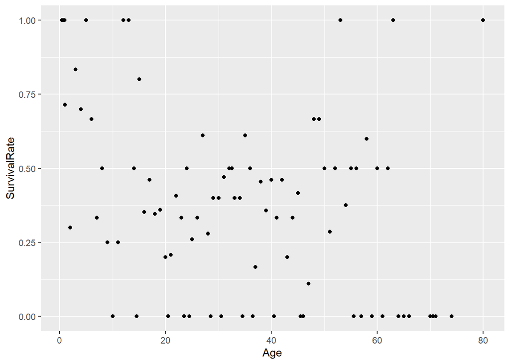

```r
ggplot(df) +
  aes(x=Age, y=SurvivalRate) +
  geom_point()
```

This isn’t too clear. Arguably, the age range 0-20 has a higher rate of survival but this plot is noisy. What if it was separated by Sex.

```r
df <- train2 %>%
  filter(is.na(Age)==FALSE) %>%
  group_by(Sex, Age) %>%
  summarise(SurvivalRate = mean(Survived),
            n = n()) %>%
  ungroup()
```

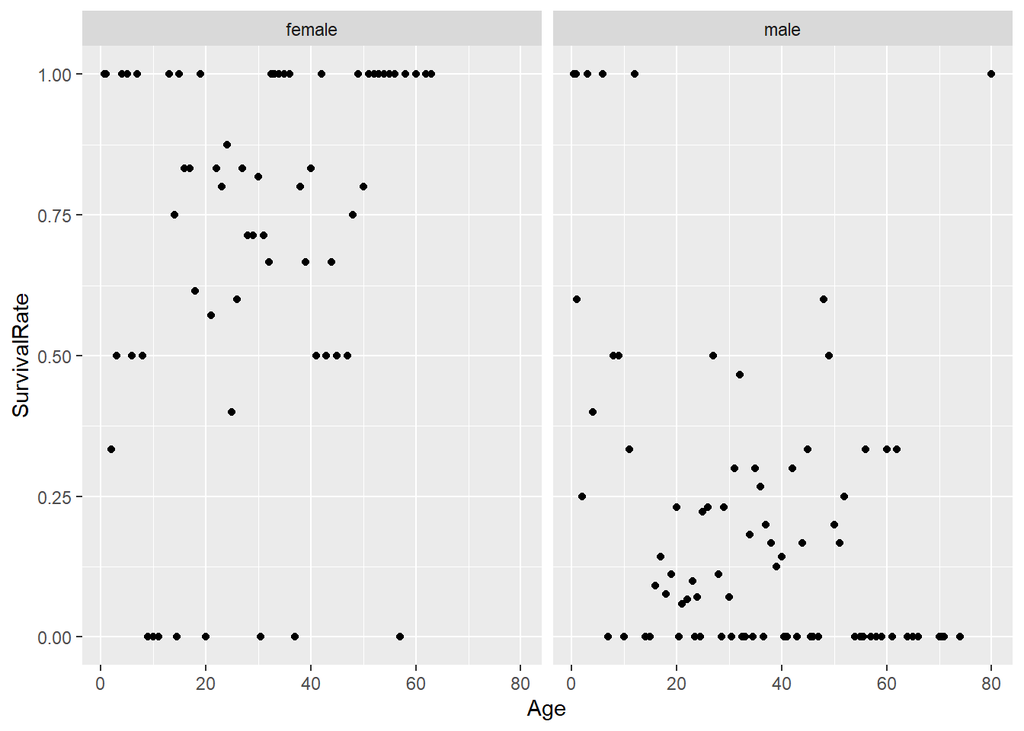

```r
ggplot(df) +
  aes(x=Age, y=SurvivalRate) +
  geom_point() +
  facet_grid(.~Sex)
```

What if it was separated by Pclass.

```r
df <- train2 %>%
  filter(is.na(Age)==FALSE) %>%
  group_by(Pclass, Age) %>%
  summarise(SurvivalRate = mean(Survived),
            n = n()) %>%
  ungroup()
```

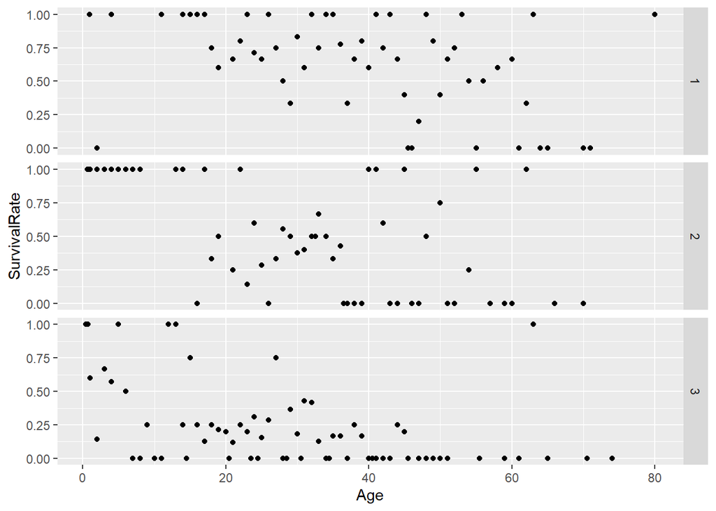

```r
ggplot(df) +
  aes(x=Age, y=SurvivalRate) +
  geom_point() +
  facet_grid(Pclass~.)
```

What if it was separated by Sex and Pclass.

```r
df <- train2 %>%
  filter(is.na(Age)==FALSE) %>%
  group_by(Sex, Pclass, Age) %>%
  summarise(SurvivalRate = mean(Survived),
            n = n()) %>%
  ungroup()
```

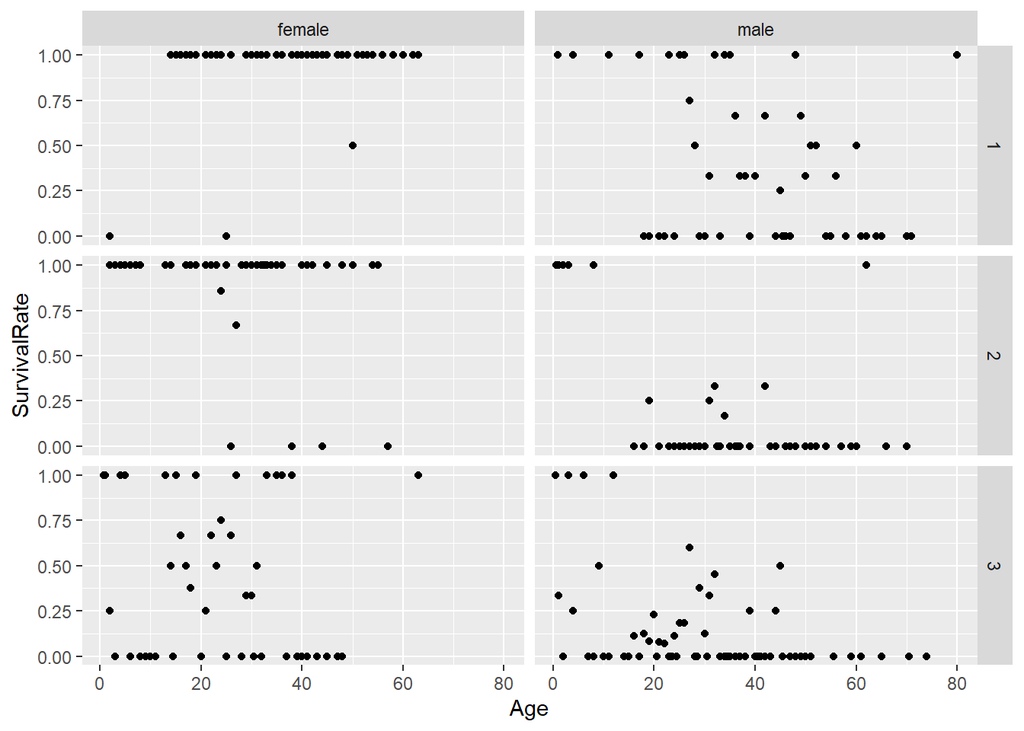

```r
ggplot(df) +
  aes(x=Age, y=SurvivalRate) +
  geom_point() +
  facet_grid(Pclass~Sex)
```

The charts are still very noisy, but it looks like younger kids have a higher chance of survival. This could be a potential predictive variable as well, but not as strong as the previous variables.

### 3.6.1 New Feature

```r
train3 <- train2 %>%
  mutate(
    AgeBin = case_when(
      is.na(Age) ~ NA_integer_,
      Age < quantile(train2$Age,0.05, na.rm = T) ~  1L,
      Age < quantile(train2$Age,0.10, na.rm = T) ~  2L,
      Age < quantile(train2$Age,0.15, na.rm = T) ~  3L,
      Age < quantile(train2$Age,0.20, na.rm = T) ~  4L,
      Age < quantile(train2$Age,0.25, na.rm = T) ~  5L,
      Age < quantile(train2$Age,0.30, na.rm = T) ~  6L,
      Age < quantile(train2$Age,0.35, na.rm = T) ~  7L,
      Age < quantile(train2$Age,0.40, na.rm = T) ~  8L,
      Age < quantile(train2$Age,0.45, na.rm = T) ~  9L,
      Age < quantile(train2$Age,0.50, na.rm = T) ~ 10L,
      Age < quantile(train2$Age,0.55, na.rm = T) ~ 11L,
      Age < quantile(train2$Age,0.60, na.rm = T) ~ 12L,
      Age < quantile(train2$Age,0.65, na.rm = T) ~ 13L,
      Age < quantile(train2$Age,0.70, na.rm = T) ~ 14L,
      Age < quantile(train2$Age,0.75, na.rm = T) ~ 15L,
      Age < quantile(train2$Age,0.80, na.rm = T) ~ 16L,
      Age < quantile(train2$Age,0.85, na.rm = T) ~ 17L,
      Age < quantile(train2$Age,0.90, na.rm = T) ~ 18L,
      Age < quantile(train2$Age,0.95, na.rm = T) ~ 19L,
      TRUE ~ 20L))
```

Let’s look at the survival rate for each AgeBin.

```r
df <- train3 %>%
  group_by(AgeBin) %>%
  summarise(
    SurvivalRate = mean(Survived),
    n = n()
  ) %>%
  ungroup()
df
```

```
## # A tibble: 21 x 3
##    AgeBin SurvivalRate     n
##     <int>        <dbl> <int>
##  1      1        0.667    30
##  2      2        0.537    41
##  3      3        0.448    29
##  4      4        0.385    39
##  5      5        0.3      40
##  6      6        0.2      25
##  7      7        0.372    43
##  8      8        0.484    31
##  9      9        0.293    41
## 10     10        0.611    18
## # ... with 11 more rows
```

Let’s plot it on a scatter plot.

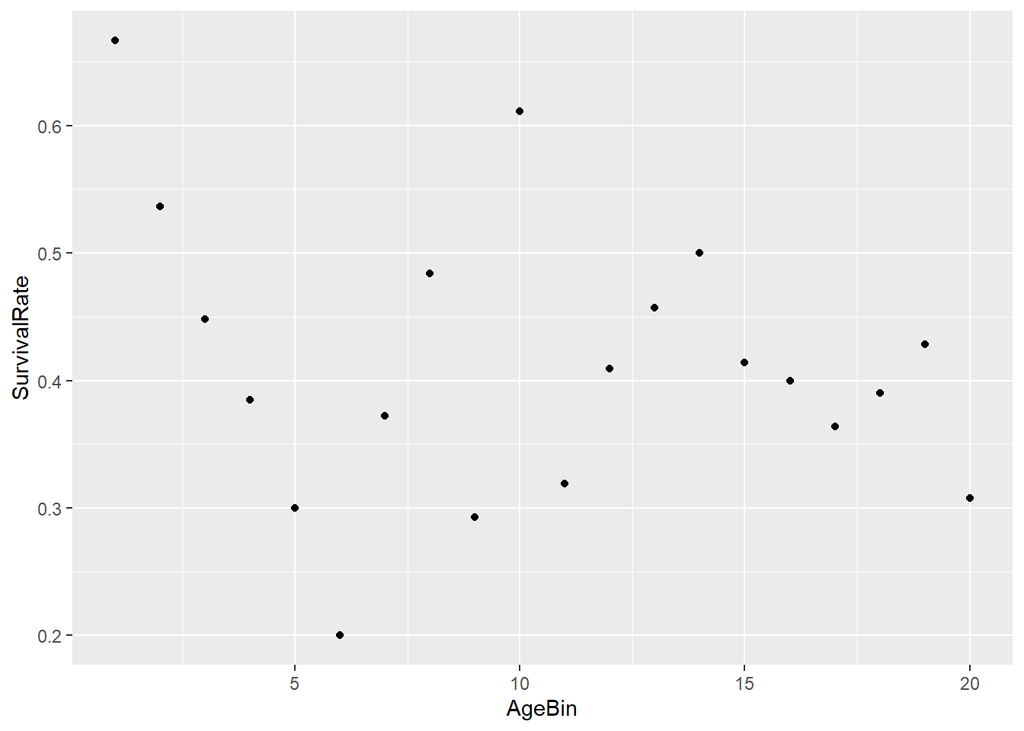

```r
ggplot(df, aes(x=AgeBin, y = SurvivalRate)) +
  geom_point()
```

Now broken up by Sex and Pclass.

```r
df <- train3 %>%
  group_by(AgeBin, Sex, Pclass) %>%
  summarise(
    SurvivalRate = mean(Survived)) %>%
  ungroup()
```

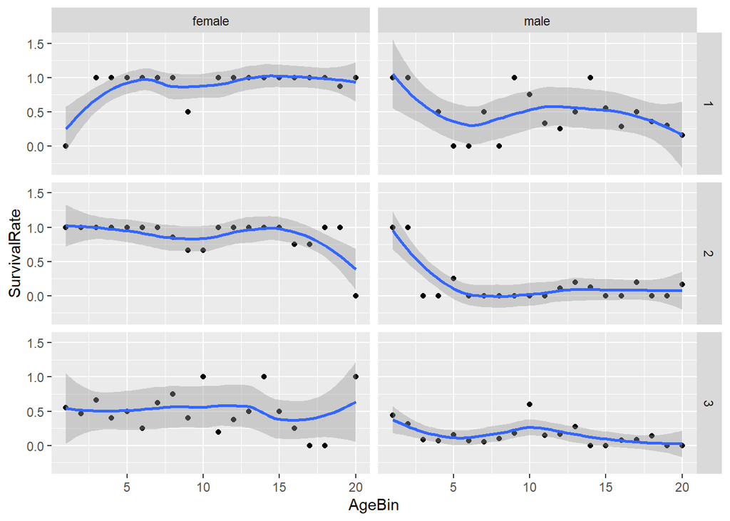

```r
ggplot(df, aes(x=AgeBin, y = SurvivalRate)) +
  geom_point() +
  facet_grid(Pclass~Sex) +
  geom_smooth()
```

Looks like younger males have a higher survival rate than those older males. This difference is more prevalent in the 1st and 2nd Pclass.

## 3.7 SibSp

The following description was provided for this column:

sibsp: The dataset defines family relations in this way…  
Sibling = brother, sister, stepbrother, stepsister  
Spouse = husband, wife (mistresses and fiancés were ignored)

Below is a quick summary:

```r
summary(train3$SibSp)
```

```
##    Min. 1st Qu.  Median    Mean 3rd Qu.    Max.
##   0.000   0.000   0.000   0.523   1.000   8.000
```

Looks like this variable counts the number of siblings someone has. Below is the average survival rate by SibSp.

```r
train3 %>%
  group_by(SibSp) %>%
  summarise(SurvivalRate = mean(Survived),
            n = n()) %>%
  ungroup()
```

```
## # A tibble: 7 x 3
##   SibSp SurvivalRate     n
##   <dbl>        <dbl> <int>
## 1     0        0.345   608
## 2     1        0.536   209
## 3     2        0.464    28
## 4     3        0.25     16
## 5     4        0.167    18
## 6     5        0         5
## 7     8        0         7
```

I don’t see any clear trend. SibSp could potentially link to the LastName feature somehow. I’m guessing if one sibling survives, so should the other. The table below shows average survival rate, sample size (n), and average number of Siblings/Spouses by last name.

```r
train3 %>%
  group_by(LastName) %>%
  summarise(SurvivalRate = mean(Survived),
            n = n(),
            SibSp = mean(SibSp)) %>%
  ungroup()
```

```
## # A tibble: 667 x 4
##    LastName  SurvivalRate     n SibSp
##    <chr>            <dbl> <int> <dbl>
##  1 Abbing             0       1     0
##  2 Abbott             0.5     2     1
##  3 Abelson            0.5     2     1
##  4 Adahl              0       1     0
##  5 Adams              0       1     0
##  6 Ahlin              0       1     1
##  7 Aks                1       1     0
##  8 Albimona           1       1     0
##  9 Alexander          0       1     0
## 10 Alhomaki           0       1     0
## # ... with 657 more rows
```

My head is spinning!… The average SibSp does not line up with n sometimes… There might be some families with the same last name.

## 3.8 Parch

The following description was provided for this column:

parch: The dataset defines family relations in this way…  
Parent = mother, father  
Child = daughter, son, stepdaughter, stepson  
Some children travelled only with a nanny, therefore parch=0 for them.

Below is a quick summary:

```r
summary(train3$Parch)
```

```
##    Min. 1st Qu.  Median    Mean 3rd Qu.    Max.
##  0.0000  0.0000  0.0000  0.3816  0.0000  6.0000
```

No NA’s. That’s good. Below is the average survival rate by Parch.

```r
train3 %>%
  group_by(Parch) %>%
  summarise(SurvivalRate = mean(Survived),
            n = n()) %>%
  ungroup()
```

```
## # A tibble: 7 x 3
##   Parch SurvivalRate     n
##   <dbl>        <dbl> <int>
## 1     0        0.344   678
## 2     1        0.551   118
## 3     2        0.5      80
## 4     3        0.6       5
## 5     4        0         4
## 6     5        0.2       5
## 7     6        0         1
```

There might be a higher survival rate for parents and their children.

## 3.9 Ticket

```r
train3 %>%
  select(Ticket) %>%
  unique() %>%
  count()
```

```
## # A tibble: 1 x 1
##       n
##   <int>
## 1   681
```

That is less than the rows of data. There must be duplicate tickets. I don’t know if this has any relevance… What else is there? Below are the first 50 ticket numbers.

```r
head(train3$Ticket, n =50)
```

```
##  [1] "A/5 21171"        "PC 17599"         "STON/O2. 3101282" "113803"
##  [5] "373450"           "330877"           "17463"            "349909"
##  [9] "347742"           "237736"           "PP 9549"          "113783"
## [13] "A/5. 2151"        "347082"           "350406"           "248706"
## [17] "382652"           "244373"           "345763"           "2649"
## [21] "239865"           "248698"           "330923"           "113788"
## [25] "349909"           "347077"           "2631"             "19950"
## [29] "330959"           "349216"           "PC 17601"         "PC 17569"
## [33] "335677"           "C.A. 24579"       "PC 17604"         "113789"
## [37] "2677"             "A./5. 2152"       "345764"           "2651"
## [41] "7546"             "11668"            "349253"           "SC/Paris 2123"
## [45] "330958"           "S.C./A.4. 23567"  "370371"           "14311"
## [49] "2662"             "349237"
```

### 3.9.1 New Features

Looks like some ticket numbers have pre-fixes. This can create two new features: TicketPrefix, TicketNo.

```r
train4 <- train3 %>%
  mutate(
    TicketPrefix = str_extract(Ticket, "^.*(?= \\d{3})"),
    TicketPrefix = str_remove_all(TicketPrefix, "\\."),
    TicketNo = case_when(
      str_detect(Ticket, " ") ~ str_extract(Ticket, "\\d*$"),
      TRUE ~ Ticket
    )
  )
```

Below is the average survival rate by TicketPrefix.

```r
train4 %>%
  group_by(TicketPrefix) %>%
  summarise(SurvivalRate = mean(Survived),
            n = n()) %>%
  ungroup()
```

```
## # A tibble: 35 x 3
##    TicketPrefix SurvivalRate     n
##    <chr>               <dbl> <int>
##  1 A/4                 0         6
##  2 A/5                 0.105    19
##  3 A/S                 0         1
##  4 A4                  0         1
##  5 A5                  0         2
##  6 C                   0.4       5
##  7 CA                  0.341    41
##  8 CA/SOTON            0         1
##  9 Fa                  0         1
## 10 FC                  0         1
## # ... with 25 more rows
```

I don’t know if this means anything. Maybe some machine learning magic can make sense of it. Below is the number of unique TicketNo.

```r
train4 %>%
  select(TicketNo) %>%
  unique() %>%
  count()
```

```
## # A tibble: 1 x 1
##       n
##   <int>
## 1   679
```

It is slightly less than the number of unique Ticket. Once again, not sure if this means anything.

## 3.10 Fare

Just like Pclass, I expect that there is a positive correlation between Fare and survival rate. Below is a summary of Fare.

```r
summary(train4$Fare)
```

```
##    Min. 1st Qu.  Median    Mean 3rd Qu.    Max.
##    0.00    7.91   14.45   32.20   31.00  512.33
```

Below is a scatter plot of Fare vs SurvivalRate.

```r
df <- train4 %>%
  group_by(Fare) %>%
  summarise(
    SurvivalRate = mean(Survived)
  ) %>%
  ungroup()
```

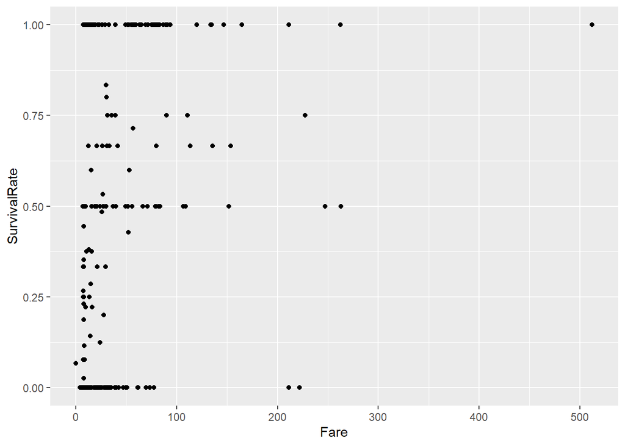

```r
ggplot(df) +
  aes(x=Fare, y=SurvivalRate) +
  geom_point()
```

Below is a scatter plot of Fare vs SurvivalRate faceted by Sex.

```r
df <- train4 %>%
  group_by(Fare, Sex) %>%
  summarise(
    SurvivalRate = mean(Survived)
  ) %>%
  ungroup()
```

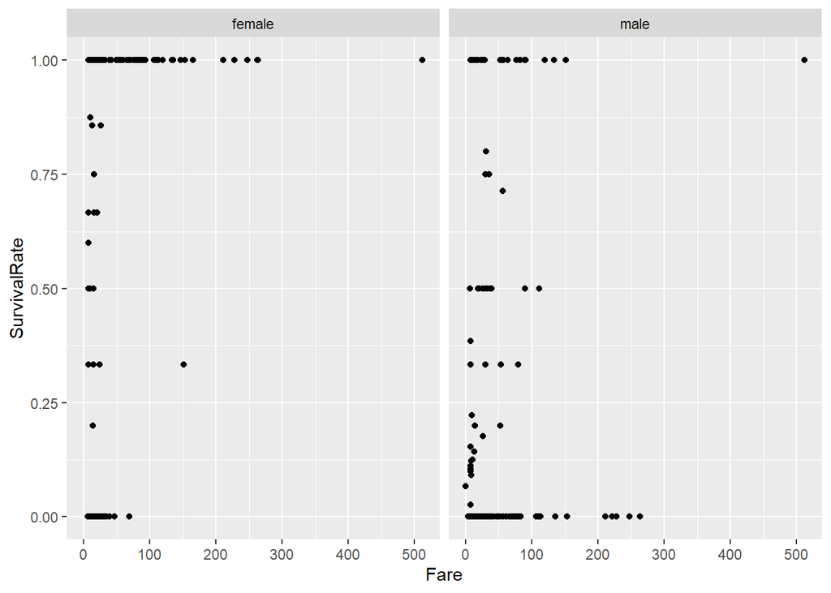

```r
ggplot(df) +
  aes(x=Fare, y=SurvivalRate) +
  geom_point() +
  facet_grid(.~Sex)
```

Looks like as Fare increases, so does survival rate. However, there is an exception for Males. It appears that a Far above $200 for males results in a low survival rate. Let’s try a different visual. The graphic below shows a histogram of survival (1) and death (0) by Fare at 10 bins.

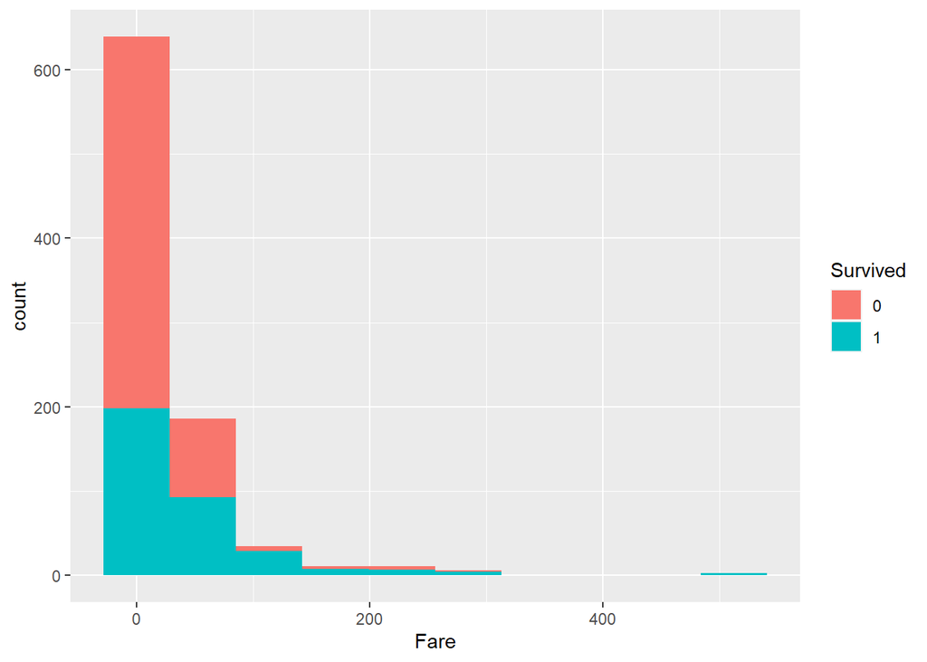

```r
df <- train4 %>%
  mutate(Pclass = as.factor(Pclass),
         Survived = as.factor(Survived),
         Sex = as.factor(Sex))

ggplot(df, aes(x=Fare, fill=Survived)) +
  geom_histogram(bins = 10)
```

Looks like survival increase as Fare increases, but it’s harder to visualize with the higher fares as the sample size decreases. To overcome this, the y axis can be converted to a percent breakout instead of a count. See below:

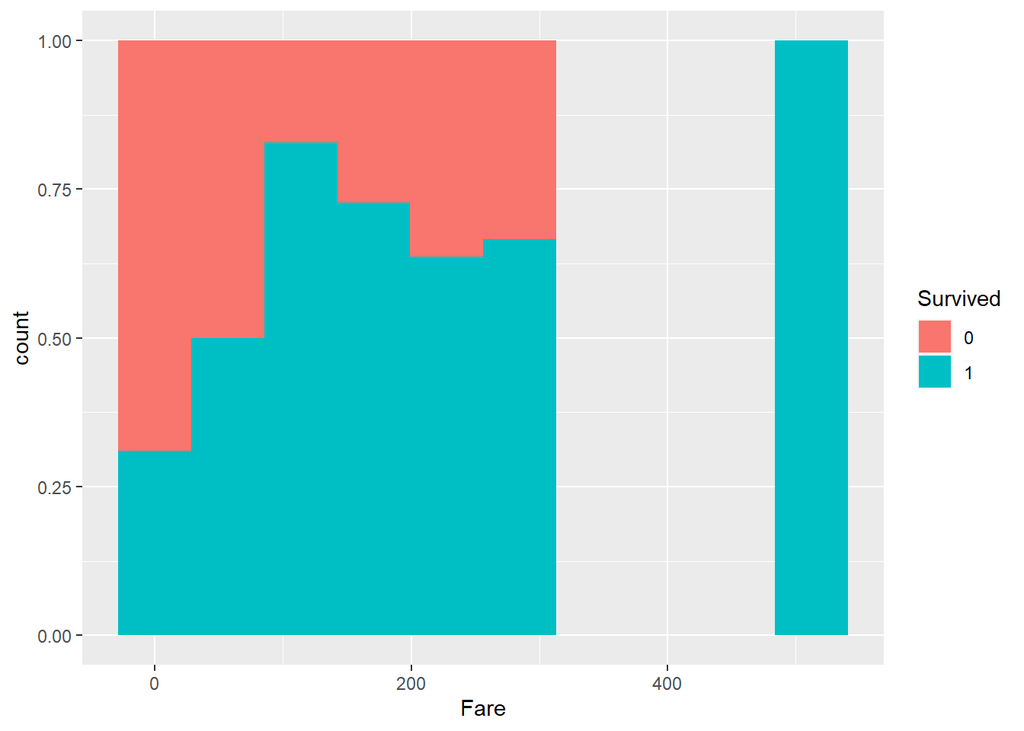

```r
ggplot(df, aes(x=Fare, fill=Survived)) +
  geom_histogram(position="fill", bins = 10)
```

That’s much easier to visualize. It appears that survival rate increase as Fare goes up and then decreases after a 200+ Fare. Also, the data past 400 might be an outlier. Let’s remove any Fare past the 99% CI and see what this graphic looks like then.

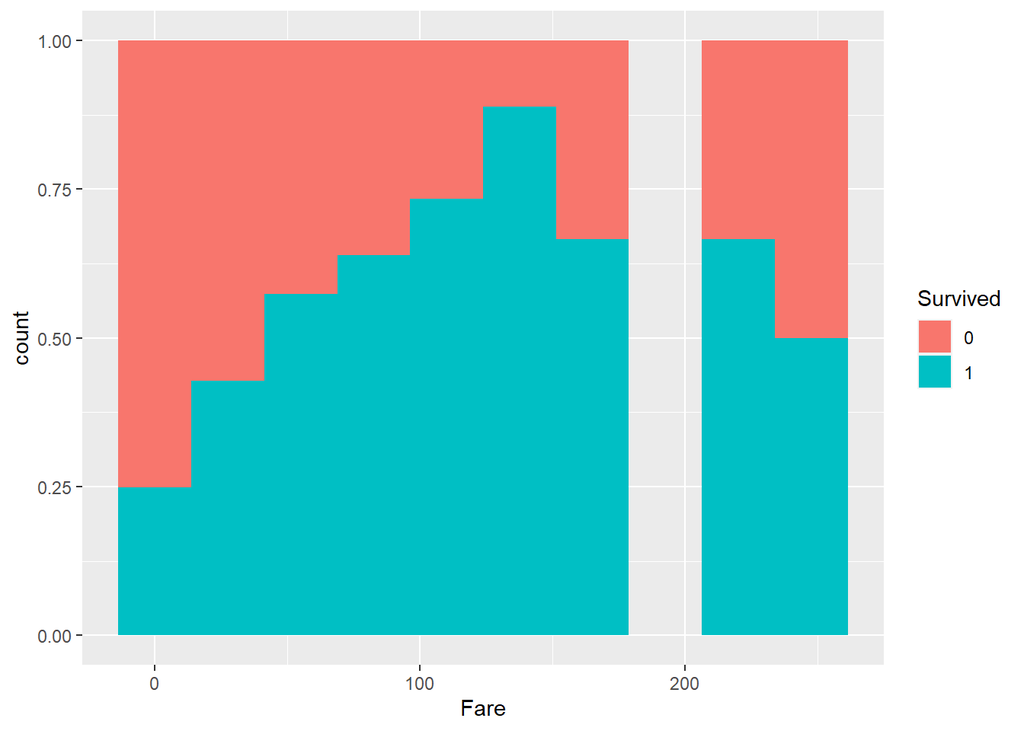

```r
df <- train4 %>%
  mutate(Pclass = as.factor(Pclass),
         Survived = as.factor(Survived),
         Sex = as.factor(Sex)) %>%
  filter(Fare < quantile(Fare, .99))

ggplot(df, aes(x=Fare, fill=Survived)) +
  geom_histogram(position="fill", bins = 10)
```

Looks like the highest change of survival is if some one but a ticket in between 100 and 200. Now let’s look at this same graphic but broken up by Pclass and Sex.

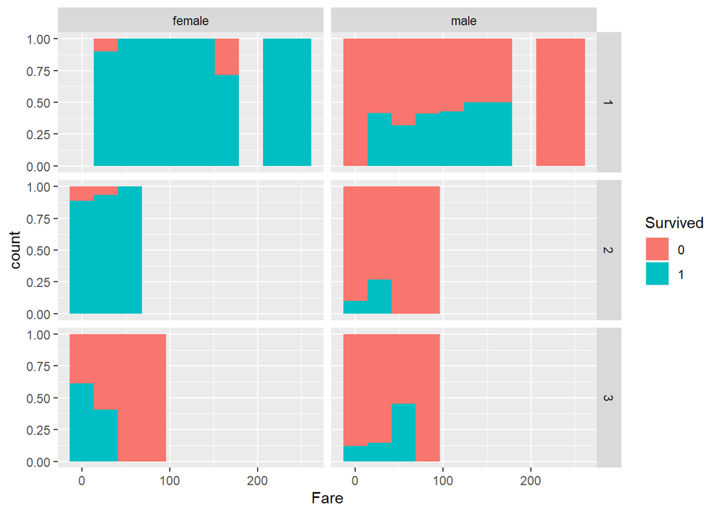

```r
ggplot(df, aes(x=Fare, fill=Survived)) +
  geom_histogram(position="fill", bins = 10) +
  facet_grid(Pclass~Sex)
```

```r
train5 <- train4 %>%
  mutate(
    FareBin = case_when(
      Fare < quantile(train4$Fare,0.05) ~  1L,
      Fare < quantile(train4$Fare,0.10) ~  2L,
      Fare < quantile(train4$Fare,0.15) ~  3L,
      Fare < quantile(train4$Fare,0.20) ~  4L,
      Fare < quantile(train4$Fare,0.25) ~  5L,
      Fare < quantile(train4$Fare,0.30) ~  6L,
      Fare < quantile(train4$Fare,0.35) ~  7L,
      Fare < quantile(train4$Fare,0.40) ~  8L,
      Fare < quantile(train4$Fare,0.45) ~  9L,
      Fare < quantile(train4$Fare,0.50) ~ 10L,
      Fare < quantile(train4$Fare,0.55) ~ 11L,
      Fare < quantile(train4$Fare,0.60) ~ 12L,
      Fare < quantile(train4$Fare,0.65) ~ 13L,
      Fare < quantile(train4$Fare,0.70) ~ 14L,
      Fare < quantile(train4$Fare,0.75) ~ 15L,
      Fare < quantile(train4$Fare,0.80) ~ 16L,
      Fare < quantile(train4$Fare,0.85) ~ 17L,
      Fare < quantile(train4$Fare,0.90) ~ 18L,
      Fare < quantile(train4$Fare,0.95) ~ 19L,
      TRUE ~ 20L))
```

Let’s look at the survival rate for each FareBin.

```r
df <- train5 %>%
  group_by(FareBin) %>%
  summarise(
    SurvivalRate = mean(Survived),
    n = n()
  ) %>%
  ungroup()
df
```

```
## # A tibble: 20 x 3
##    FareBin SurvivalRate     n
##      <int>        <dbl> <int>
##  1       1       0.0698    43
##  2       2       0.2       45
##  3       3       0.278     18
##  4       4       0.317     60
##  5       5       0.140     57
##  6       6       0.474     19
##  7       7       0.130     69
##  8       8       0.179     28
##  9       9       0.489     47
## 10      10       0.389     54
## 11      11       0.378     45
## 12      12       0.429     49
## 13      13       0.419     31
## 14      14       0.561     57
## 15      15       0.386     44
## 16      16       0.419     43
## 17      17       0.413     46
## 18      18       0.543     46
## 19      19       0.778     45
## 20      20       0.756     45
```

Let’s plot it on a scatter plot.

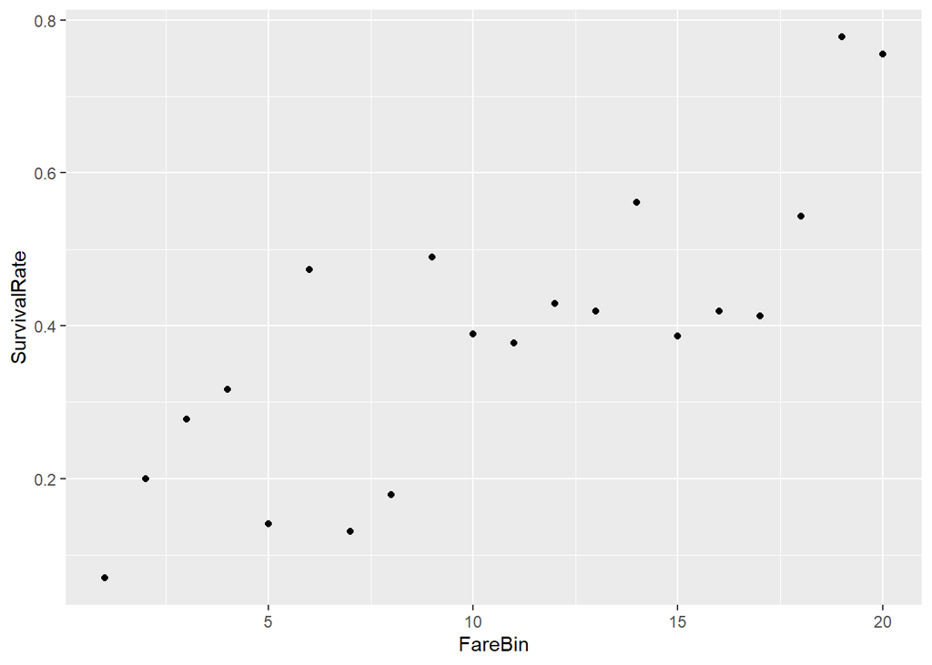

```r
ggplot(df, aes(x=FareBin, y = SurvivalRate)) +
  geom_point()
```

Now broken up by Sex and Pclass.

```r
df <- train5 %>%
  group_by(FareBin, Sex, Pclass) %>%
  summarise(
    SurvivalRate = mean(Survived),
    n = n()
  ) %>%
  ungroup()
```

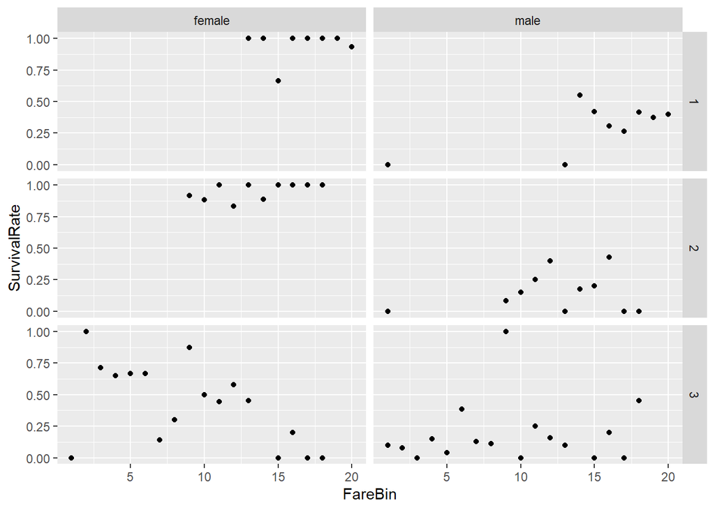

```r
ggplot(df, aes(x=FareBin, y = SurvivalRate)) +
  geom_point() +
  facet_grid(Pclass~Sex)
```

This affirms some of the previous observations.

## 3.11 Cabin

Below is count of each Cabin.

```r
train5 %>%
  group_by(Cabin) %>%
  count() %>%
  ungroup()
```

```
## # A tibble: 148 x 2
##    Cabin     n
##    <chr> <int>
##  1 A10       1
##  2 A14       1
##  3 A16       1
##  4 A19       1
##  5 A20       1
##  6 A23       1
##  7 A24       1
##  8 A26       1
##  9 A31       1
## 10 A32       1
## # ... with 138 more rows
```

There are 687 NA’s. The letter in front could signify which floor a passenger is on. This might correlate to Pclass and SurvivalRate. This can become a new feature and potentially a predictive variable. Also, some have multiple Cabin numbers. The count of cabins could become a feature as well. But first… there are some weird Cabin numbers that need a deeper look: ones that have two letters and one that is just the letter T.

```r
train5 %>%
  filter(
    str_detect(Cabin,"F E69|F G63|F G73|T|F2|F33|F38|F4|G6")) %>%
  select(Survived,Pclass,Name,Sex,Age,Cabin)
```

```
## # A tibble: 18 x 6
##    Survived Pclass Name                                        Sex     Age Cabin
##       <dbl>  <dbl> <chr>                                       <chr> <dbl> <chr>
##  1        1      3 "Sandstrom, Miss. Marguerite Rut"           fema~   4   G6
##  2        1      2 "Nye, Mrs. (Elizabeth Ramell)"              fema~  29   F33
##  3        0      3 "Moen, Mr. Sigurd Hansen"                   male   25   F G73
##  4        1      3 "Peter, Miss. Anna"                         fema~  NA   F E69
##  5        0      2 "Navratil, Mr. Michel (\"Louis M Hoffman\"~ male   36.5 F2
##  6        1      2 "Becker, Master. Richard F"                 male    1   F4
##  7        1      2 "Navratil, Master. Michel M"                male    3   F2
##  8        0      3 "Strom, Miss. Telma Matilda"                fema~   2   G6
##  9        0      3 "Strom, Mrs. Wilhelm (Elna Matilda Persson~ fema~  29   G6
## 10        0      1 "Blackwell, Mr. Stephen Weart"              male   45   T
## 11        1      2 "Navratil, Master. Edmond Roger"            male    2   F2
## 12        1      2 "Brown, Miss. Amelia \"Mildred\""           fema~  24   F33
## 13        1      3 "Sandstrom, Mrs. Hjalmar (Agnes Charlotta ~ fema~  24   G6
## 14        1      2 "Lemore, Mrs. (Amelia Milley)"              fema~  34   F33
## 15        1      2 "Becker, Miss. Marion Louise"               fema~   4   F4
## 16        0      3 "Humblen, Mr. Adolf Mathias Nicolai Olsen"  male   42   F G63
## 17        0      3 "Soholt, Mr. Peter Andreas Lauritz Anderse~ male   19   F G73
## 18        0      3 "Tobin, Mr. Roger"                          male   NA   F38
```

```r
train6 <- train5 %>%
  mutate(
    CabinLevel = str_extract(Cabin,"^."),
    CabinQty =
      str_count(Cabin, "[:alpha:]\\d{1,3}")
  )
```

Below is the survival rate by CabinLevel.

```r
train6 %>%
  group_by(CabinLevel) %>%
  summarise(SurvivalRate = mean(Survived),
            n = n()) %>%
  ungroup()
```

```
## # A tibble: 9 x 3
##   CabinLevel SurvivalRate     n
##   <chr>             <dbl> <int>
## 1 A                 0.467    15
## 2 B                 0.745    47
## 3 C                 0.593    59
## 4 D                 0.758    33
## 5 E                 0.75     32
## 6 F                 0.615    13
## 7 G                 0.5       4
## 8 T                 0         1
## 9 <NA>              0.300   687
```

```r
train6 %>%
  group_by(CabinQty) %>%
  summarise(SurvivalRate = mean(Survived),
            n = n()) %>%
  ungroup()
```

```
## # A tibble: 6 x 3
##   CabinQty SurvivalRate     n
##      <int>        <dbl> <int>
## 1        0        0.5       4
## 2        1        0.672   180
## 3        2        0.667    12
## 4        3        0.5       6
## 5        4        1         2
## 6       NA        0.300   687
```

This just re-affirms what was stated earlier. Those with cabin numbers had a higher survival rate. I wonder if only higher Pclass passengers had their Cabin recorded? Below is the survival rate and sample size of all the rows of data that included a cabin number:

```r
train6 %>%
  filter(is.na(CabinLevel)==FALSE) %>%
  group_by(Pclass) %>%
  summarise(SurvivalRate = mean(Survived),
            n = n()) %>%
  ungroup()
```

```
## # A tibble: 3 x 3
##   Pclass SurvivalRate     n
##    <dbl>        <dbl> <int>
## 1      1        0.665   176
## 2      2        0.812    16
## 3      3        0.5      12
```

Just as expected, the majority are in Pclass 1. How do these survival rates stack up against the average survival rate of those without a cabin number? Below are the survival rates of all those without a cabin number:

```r
train6 %>%
  filter(is.na(CabinLevel)) %>%
  group_by(Pclass) %>%
  summarise(SurvivalRate = mean(Survived),
            n = n()) %>%
  ungroup()
```

```
## # A tibble: 3 x 3
##   Pclass SurvivalRate     n
##    <dbl>        <dbl> <int>
## 1      1        0.475    40
## 2      2        0.440   168
## 3      3        0.236   479
```

Those with a cabin number have a higher survival rate than those without. Therfore, this should be made a feature. NoCabin will be FALSE if there is a cabin number and TRUE if there is not one.

```r
train7 <- train6 %>%
  mutate(
    NoCabin = is.na(Cabin)
  )
```

This could be a good predictive variable.

## 3.12 Embarked

The description of Embarked say:  
C = Cherbourg,  
Q = Queenstown,  
S = Southampton  
Below is the survival rate by embarkment port:

```r
train7 %>%
  group_by(Embarked) %>%
  summarise(SurvivalRate = mean(Survived),
            n = n()) %>%
  ungroup()
```

```
## # A tibble: 4 x 3
##   Embarked SurvivalRate     n
##   <chr>           <dbl> <int>
## 1 C               0.554   168
## 2 Q               0.390    77
## 3 S               0.337   644
## 4 <NA>            1         2
```

Below is the survival rate by embarkment port and Pclass:

```r
train7 %>%
  group_by(Embarked, Pclass) %>%
  summarise(SurvivalRate = mean(Survived),
            n = n()) %>%
  ungroup()
```

```
## # A tibble: 10 x 4
##    Embarked Pclass SurvivalRate     n
##    <chr>     <dbl>        <dbl> <int>
##  1 C             1        0.694    85
##  2 C             2        0.529    17
##  3 C             3        0.379    66
##  4 Q             1        0.5       2
##  5 Q             2        0.667     3
##  6 Q             3        0.375    72
##  7 S             1        0.583   127
##  8 S             2        0.463   164
##  9 S             3        0.190   353
## 10 <NA>          1        1         2
```

Below is the survival rate by embarkment port and Sex:

```r
train7 %>%
  group_by(Embarked, Sex) %>%
  summarise(SurvivalRate = mean(Survived),
            n = n()) %>%
  ungroup()
```

```
## # A tibble: 7 x 4
##   Embarked Sex    SurvivalRate     n
##   <chr>    <chr>         <dbl> <int>
## 1 C        female       0.877     73
## 2 C        male         0.305     95
## 3 Q        female       0.75      36
## 4 Q        male         0.0732    41
## 5 S        female       0.690    203
## 6 S        male         0.175    441
## 7 <NA>     female       1          2
```

Embarked may be a good predictive variable as well.

# 4 Conclusion

Pclass and Sex appear to be the strongest predictive variables. This will be confirmed during the model building EDA. There may be more feature engineering to come but I think this is a good start.